[figure not shown]

# Data Frame-ak

Kurtso honen hasieran esan bezala, `R` estatistikara eta grafikoetara bideratutiko programazio-lengoaia da eta horretarako, argi dagoen bezala datuak behar dira. Aldi berean, datuak forma eta mota askotakoak izan daitezke eta ahal den neurrian datu horiek egituratzea eta ordenatzea oso interesgarria izango da analisirako. Hor sartzen dira jokoan hain zuzen ere **Data Frame**-ak.

**Data Frame**-ak, datu taulak dira, matrize egitura dutelarik. Seguraski, gaur egun taulak sortzeko erabiltzen den programarik ezagunenetakoena **Microsoft Excel** izango da. Bertan gauza desberdin asko egin daitezkeen arren, programaren funtsa taulekin lana egitea da.

Esan bezala, **Data Frame**-ak matrize itxurako taulak dira, baina askoz moldagarriagoak eta eraginkorragoak kasu askotan. **Data Frame**-etan, zutabe bakoitzak formatu ezberdin bat izan dezake (karaktere-kateak, zenbakiak, aldagai logikoak, faktoreak…) eta matrizeetan hori ez da posible.

Sarrera honen ondoren, has gaitezen adibide bat ikusten.

- **OHAR GARRANTZITSUA:** *Data Frame-ak, `R`-n taulak sortzeko era estandarra eta oinarrizkoa da, baina hala ere azkarragoa eta eraginkorragoa den beste bat existitzen da: **Data Table**-a. Data Table-ak hurrengo koadernoan azaltzen dira eta sintaxi aldetik desberdintasunak daude. Funtsean biak dira Data Frame-ak, baina esan bezala sintaxi ezberdina dute eta Data Table-ak eraginkorragoak dira orokorrean.*

*Beraz, irakurleak hurrengo galdera egin dezake: zein ikastea da gomendagarriagoa? Galdera honek ez du erantzun zehatzik, baina nire gomendioa biak ikastea da. Hala ere, blog eta diskusio askotan bietako bat ikastekotan **Data Table**-ak ikastea gomendatzen da orokorrean, aurretik aipatutako arrazoiengatik.*

> - [data.table vs. data.frame](https://www.analyticsvidhya.com/blog/2016/05/data-table-data-frame-work-large-data-sets/)
> - [What is the practical difference between data.frame and data.table in R](https://stackoverflow.com/questions/18001120/what-is-the-practical-difference-between-data-frame-and-data-table-in-r)

Ohar horren ondoren, **Data Frame**-ekin hasiko gara. Horretarako, `R`-k berez dakarren `mtcars` taula erabiliko dugu.

```r
mtcars
```

```
##                      mpg cyl  disp  hp drat    wt  qsec vs am gear carb
## Mazda RX4           21.0   6 160.0 110 3.90 2.620 16.46  0  1    4    4
## Mazda RX4 Wag       21.0   6 160.0 110 3.90 2.875 17.02  0  1    4    4
## Datsun 710          22.8   4 108.0  93 3.85 2.320 18.61  1  1    4    1
## Hornet 4 Drive      21.4   6 258.0 110 3.08 3.215 19.44  1  0    3    1
## Hornet Sportabout   18.7   8 360.0 175 3.15 3.440 17.02  0  0    3    2
## Valiant             18.1   6 225.0 105 2.76 3.460 20.22  1  0    3    1
## Duster 360          14.3   8 360.0 245 3.21 3.570 15.84  0  0    3    4
## Merc 240D           24.4   4 146.7  62 3.69 3.190 20.00  1  0    4    2
## Merc 230            22.8   4 140.8  95 3.92 3.150 22.90  1  0    4    2
## Merc 280            19.2   6 167.6 123 3.92 3.440 18.30  1  0    4    4
## Merc 280C           17.8   6 167.6 123 3.92 3.440 18.90  1  0    4    4
## Merc 450SE          16.4   8 275.8 180 3.07 4.070 17.40  0  0    3    3
## Merc 450SL          17.3   8 275.8 180 3.07 3.730 17.60  0  0    3    3
## Merc 450SLC         15.2   8 275.8 180 3.07 3.780 18.00  0  0    3    3
## Cadillac Fleetwood  10.4   8 472.0 205 2.93 5.250 17.98  0  0    3    4
## Lincoln Continental 10.4   8 460.0 215 3.00 5.424 17.82  0  0    3    4
## Chrysler Imperial   14.7   8 440.0 230 3.23 5.345 17.42  0  0    3    4
## Fiat 128            32.4   4  78.7  66 4.08 2.200 19.47  1  1    4    1
## Honda Civic         30.4   4  75.7  52 4.93 1.615 18.52  1  1    4    2
## Toyota Corolla      33.9   4  71.1  65 4.22 1.835 19.90  1  1    4    1
## Toyota Corona       21.5   4 120.1  97 3.70 2.465 20.01  1  0    3    1
## Dodge Challenger    15.5   8 318.0 150 2.76 3.520 16.87  0  0    3    2
## AMC Javelin         15.2   8 304.0 150 3.15 3.435 17.30  0  0    3    2
## Camaro Z28          13.3   8 350.0 245 3.73 3.840 15.41  0  0    3    4
## Pontiac Firebird    19.2   8 400.0 175 3.08 3.845 17.05  0  0    3    2
## Fiat X1-9           27.3   4  79.0  66 4.08 1.935 18.90  1  1    4    1
## Porsche 914-2       26.0   4 120.3  91 4.43 2.140 16.70  0  1    5    2
## Lotus Europa        30.4   4  95.1 113 3.77 1.513 16.90  1  1    5    2
## Ford Pantera L      15.8   8 351.0 264 4.22 3.170 14.50  0  1    5    4
## Ferrari Dino        19.7   6 145.0 175 3.62 2.770 15.50  0  1    5    6
## Maserati Bora       15.0   8 301.0 335 3.54 3.570 14.60  0  1    5    8
## Volvo 142E          21.4   4 121.0 109 4.11 2.780 18.60  1  1    4    2
```

Orokorrean, oso garrantzitsua izaten da hurrengo egitura mantentzea Data Frame-etan:

- Zutabeetan *aldagaiak*
- Errenkadetan *elementuak*

Adibide honetan, *aldagaiak*:

- `mpg`, `cyl`, `disp`, `hp`, `drat`, `wt`, `qsec`, `vs`, `am`, `gear` eta `carb` dira.

eta *elementuak* berriz kotxe markak:

- Mazda RX4, Mazda RX4 Wag, Datsun 710…

Aldagai bakoitzak bere esanahia du, adibidez `mpg` gasolina kontsumoa da (*miles per gallon*), `hp` zaldi-potentzia da (*horsepower*) eta `cyl` zilindro kopurua (*cylinders*). Taula horren informazio gehiago lortzeko hurrengo lerroa exekuta dezakegu:

```r
?mtcars
```

```
## starting httpd help server ... done
```

Taulen hasierako ideia bat egiteko, hurrengo 5 funtzioak erabili ditzazkegu besteak beste:

- `dim`: taularen dimentsioak ezagutzeko (elementu eta aldagai kopurua)
- `names`: aldagaiak ezagutzeko
- `summary`: taulako aldagai bakoitzaren laburpen bat egiten du, oinarrizko datu estatistiko batzuk emanez.
- `head` / `tail`: hasierako/amaierako elementuak erakusteko
- `str`: taularen egitura azaltzen du (dimentsioa, aldagaiak eta aldagai motak)

```r
dim(mtcars)
```

```
## [1] 32 11
```

```r
names(mtcars)
```

```
##  [1] "mpg"  "cyl"  "disp" "hp"   "drat" "wt"   "qsec" "vs"   "am"   "gear"
## [11] "carb"
```

```r
summary(mtcars)
```

```
##       mpg             cyl             disp             hp
##  Min.   :10.40   Min.   :4.000   Min.   : 71.1   Min.   : 52.0
##  1st Qu.:15.43   1st Qu.:4.000   1st Qu.:120.8   1st Qu.: 96.5
##  Median :19.20   Median :6.000   Median :196.3   Median :123.0
##  Mean   :20.09   Mean   :6.188   Mean   :230.7   Mean   :146.7
##  3rd Qu.:22.80   3rd Qu.:8.000   3rd Qu.:326.0   3rd Qu.:180.0
##  Max.   :33.90   Max.   :8.000   Max.   :472.0   Max.   :335.0
##       drat             wt             qsec             vs
##  Min.   :2.760   Min.   :1.513   Min.   :14.50   Min.   :0.0000
##  1st Qu.:3.080   1st Qu.:2.581   1st Qu.:16.89   1st Qu.:0.0000
##  Median :3.695   Median :3.325   Median :17.71   Median :0.0000
##  Mean   :3.597   Mean   :3.217   Mean   :17.85   Mean   :0.4375
##  3rd Qu.:3.920   3rd Qu.:3.610   3rd Qu.:18.90   3rd Qu.:1.0000
##  Max.   :4.930   Max.   :5.424   Max.   :22.90   Max.   :1.0000
##        am              gear            carb
##  Min.   :0.0000   Min.   :3.000   Min.   :1.000
##  1st Qu.:0.0000   1st Qu.:3.000   1st Qu.:2.000
##  Median :0.0000   Median :4.000   Median :2.000
##  Mean   :0.4062   Mean   :3.688   Mean   :2.812
##  3rd Qu.:1.0000   3rd Qu.:4.000   3rd Qu.:4.000
##  Max.   :1.0000   Max.   :5.000   Max.   :8.000
```

```r
head(mtcars)
```

```
##                    mpg cyl disp  hp drat    wt  qsec vs am gear carb
## Mazda RX4         21.0   6  160 110 3.90 2.620 16.46  0  1    4    4
## Mazda RX4 Wag     21.0   6  160 110 3.90 2.875 17.02  0  1    4    4
## Datsun 710        22.8   4  108  93 3.85 2.320 18.61  1  1    4    1
## Hornet 4 Drive    21.4   6  258 110 3.08 3.215 19.44  1  0    3    1
## Hornet Sportabout 18.7   8  360 175 3.15 3.440 17.02  0  0    3    2
## Valiant           18.1   6  225 105 2.76 3.460 20.22  1  0    3    1
```

```r
str(mtcars)
```

```
## 'data.frame':    32 obs. of  11 variables:
##  $ mpg : num  21 21 22.8 21.4 18.7 18.1 14.3 24.4 22.8 19.2 ...
##  $ cyl : num  6 6 4 6 8 6 8 4 4 6 ...
##  $ disp: num  160 160 108 258 360 ...
##  $ hp  : num  110 110 93 110 175 105 245 62 95 123 ...
##  $ drat: num  3.9 3.9 3.85 3.08 3.15 2.76 3.21 3.69 3.92 3.92 ...
##  $ wt  : num  2.62 2.88 2.32 3.21 3.44 ...
##  $ qsec: num  16.5 17 18.6 19.4 17 ...
##  $ vs  : num  0 0 1 1 0 1 0 1 1 1 ...
##  $ am  : num  1 1 1 0 0 0 0 0 0 0 ...
##  $ gear: num  4 4 4 3 3 3 3 4 4 4 ...
##  $ carb: num  4 4 1 1 2 1 4 2 2 4 ...
```

Azter daitekeen bezala, funtzio batzuk informazio berdina edo antzekoa ematen dute, baina beharren eta kasuaren arabera horietako bat edo beste erabili daiteke. Adibide honetatik hurrengo informazioa atera daiteke:

- 32 elementu
- 11 aldagai
- Aldagai guztiak zenbakizkoak (`num`)

## Zutabeak, errenkadak eta elementuak aukeratzen

Data Frame-etako elementuak, matrizeetako elementuen era berdinean lor daitezke, hau da, `[]` erabiliz:

```r
#1. zutabea
mtcars[,1]
```

```
##  [1] 21.0 21.0 22.8 21.4 18.7 18.1 14.3 24.4 22.8 19.2 17.8 16.4 17.3 15.2
## [15] 10.4 10.4 14.7 32.4 30.4 33.9 21.5 15.5 15.2 13.3 19.2 27.3 26.0 30.4
## [29] 15.8 19.7 15.0 21.4
```

```r
#20. errenkada
mtcars[20,]
```

```
##                 mpg cyl disp hp drat    wt qsec vs am gear carb
## Toyota Corolla 33.9   4 71.1 65 4.22 1.835 19.9  1  1    4    1
```

```r
#'Datsun 710' kotxearen zaldi-potentzia ('hp')
mtcars["Datsun 710","hp"]
```

```
## [1] 93
```

Bestalde, zutabeak lortzeko beste bi metodo daude:

- `[[]]`
- `$` (Honetarako zutabeek izena izan behar dute)

```r
#5. zutabea
mtcars[[5]]
```

```
##  [1] 3.90 3.90 3.85 3.08 3.15 2.76 3.21 3.69 3.92 3.92 3.92 3.07 3.07 3.07
## [15] 2.93 3.00 3.23 4.08 4.93 4.22 3.70 2.76 3.15 3.73 3.08 4.08 4.43 3.77
## [29] 4.22 3.62 3.54 4.11
```

```r
#'drat' zutabea
mtcars[["drat"]]
```

```
##  [1] 3.90 3.90 3.85 3.08 3.15 2.76 3.21 3.69 3.92 3.92 3.92 3.07 3.07 3.07
## [15] 2.93 3.00 3.23 4.08 4.93 4.22 3.70 2.76 3.15 3.73 3.08 4.08 4.43 3.77
## [29] 4.22 3.62 3.54 4.11
```

```r
#'mpg' zutabea
mtcars$mpg
```

```
##  [1] 21.0 21.0 22.8 21.4 18.7 18.1 14.3 24.4 22.8 19.2 17.8 16.4 17.3 15.2
## [15] 10.4 10.4 14.7 32.4 30.4 33.9 21.5 15.5 15.2 13.3 19.2 27.3 26.0 30.4
## [29] 15.8 19.7 15.0 21.4
```

`$` metodoa oso erabilgarria izaten da balio zehatz bat duten elementuak aukeratzeko orduan, adibidez:

```r
#'cyl' aldagaian 6 zenbakia duten elementuak
mtcars[mtcars$cyl == 6,]
```

```
##                 mpg cyl  disp  hp drat    wt  qsec vs am gear carb
## Mazda RX4      21.0   6 160.0 110 3.90 2.620 16.46  0  1    4    4
## Mazda RX4 Wag  21.0   6 160.0 110 3.90 2.875 17.02  0  1    4    4
## Hornet 4 Drive 21.4   6 258.0 110 3.08 3.215 19.44  1  0    3    1
## Valiant        18.1   6 225.0 105 2.76 3.460 20.22  1  0    3    1
## Merc 280       19.2   6 167.6 123 3.92 3.440 18.30  1  0    4    4
## Merc 280C      17.8   6 167.6 123 3.92 3.440 18.90  1  0    4    4
## Ferrari Dino   19.7   6 145.0 175 3.62 2.770 15.50  0  1    5    6
```

```r
#'cyl' aldagaian 6 zenbakia eta 'hp' aldagaian 110 duten elementuak
mtcars[mtcars$cyl == 6 & mtcars$hp == 110,]
```

```
##                 mpg cyl disp  hp drat    wt  qsec vs am gear carb
## Mazda RX4      21.0   6  160 110 3.90 2.620 16.46  0  1    4    4
## Mazda RX4 Wag  21.0   6  160 110 3.90 2.875 17.02  0  1    4    4
## Hornet 4 Drive 21.4   6  258 110 3.08 3.215 19.44  1  0    3    1
```

```r
#'cyl' aldagaian 6 zenbakia eta 'hp' aldagaian 110 duten elementuak
#Erakutsi 'wt' eta 'drat' aldagaiak bakarrik
mtcars[mtcars$cyl == 6 & mtcars$hp == 110, c("wt","drat")]
```

```
##                   wt drat
## Mazda RX4      2.620 3.90
## Mazda RX4 Wag  2.875 3.90
## Hornet 4 Drive 3.215 3.08
```

- **Oharra:** `mtcars$` idatzi ondoren TABULAZIO (`Tab`) botoia sakatu ezkero, erabilgarri dauden aldagaien lista agertuko da.

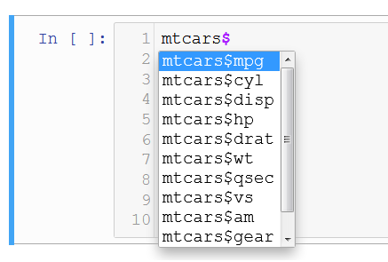

Data Frame-ean zutabe multzo batekin geratzea nahi baldin bada `subset` funtzioa erabili daiteke:

```r
df <- subset(mtcars, select = c(mpg, cyl, am))

head(df)
```

```
##                    mpg cyl am
## Mazda RX4         21.0   6  1
## Mazda RX4 Wag     21.0   6  1
## Datsun 710        22.8   4  1
## Hornet 4 Drive    21.4   6  0
## Hornet Sportabout 18.7   8  0
## Valiant           18.1   6  0
```

Taulatik zutabe multzo bat ezabatzea nahi izanez gero aldiz `subset` erabiltzerakoan, `select`-en partean `-` ikurra erabiliko dugu:

```r
df <- subset(mtcars, select = -c(mpg, cyl, am))

head(df)
```

```
##                   disp  hp drat    wt  qsec vs gear carb
## Mazda RX4          160 110 3.90 2.620 16.46  0    4    4
## Mazda RX4 Wag      160 110 3.90 2.875 17.02  0    4    4
## Datsun 710         108  93 3.85 2.320 18.61  1    4    1
## Hornet 4 Drive     258 110 3.08 3.215 19.44  1    3    1
## Hornet Sportabout  360 175 3.15 3.440 17.02  0    3    2
## Valiant            225 105 2.76 3.460 20.22  1    3    1
```

**Oharra:** *Konturatu hurrengo kasuak desberdinak direla*

```r
#Metodo hauen bidez BEKTORE bat sortzen da
class(mtcars$mpg)
```

```
## [1] "numeric"
```

```r
mtcars$mpg
```

```
##  [1] 21.0 21.0 22.8 21.4 18.7 18.1 14.3 24.4 22.8 19.2 17.8 16.4 17.3 15.2
## [15] 10.4 10.4 14.7 32.4 30.4 33.9 21.5 15.5 15.2 13.3 19.2 27.3 26.0 30.4
## [29] 15.8 19.7 15.0 21.4
```

```r
#mtcars[["mpg"]]
#mtcars[,"mpg"]
```

```r
#Metodo honen bidez DATA.FRAME bat sortzen da
class(mtcars["mpg"])
```

```
## [1] "data.frame"
```

```r
mtcars["mpg"]
```

```
##                      mpg
## Mazda RX4           21.0
## Mazda RX4 Wag       21.0
## Datsun 710          22.8
## Hornet 4 Drive      21.4
## Hornet Sportabout   18.7
## Valiant             18.1
## Duster 360          14.3
## Merc 240D           24.4
## Merc 230            22.8
## Merc 280            19.2
## Merc 280C           17.8
## Merc 450SE          16.4
## Merc 450SL          17.3
## Merc 450SLC         15.2
## Cadillac Fleetwood  10.4
## Lincoln Continental 10.4
## Chrysler Imperial   14.7
## Fiat 128            32.4
## Honda Civic         30.4
## Toyota Corolla      33.9
## Toyota Corona       21.5
## Dodge Challenger    15.5
## AMC Javelin         15.2
## Camaro Z28          13.3
## Pontiac Firebird    19.2
## Fiat X1-9           27.3
## Porsche 914-2       26.0
## Lotus Europa        30.4
## Ford Pantera L      15.8
## Ferrari Dino        19.7
## Maserati Bora       15.0
## Volvo 142E          21.4
```

## Faktoreak

Koaderno honen hasieran esan bezala, Data Frame-en bidez zutabe bakoitza aldagai-mota ezberdinekoa izan daiteke. `mtcars`-en kasuan, ikusi den bezala zutabe guztiak zenbakizkoak edo numerikoak (`num`) dira, hala ere aldaketa batzuk egingo ditugu aurrerago.

Azpi-atal honetan, **faktoreekin** sartuko gara, tauletan garrantzi berezia duten aldagai-mota. **Faktoreek** aukera finitu jakin bat eskaintzen dute eta aukera horietara mugatzen dira. Demagun adibidez inkesta batean azken astean telebista ikusi den edo ez galdetzen dela. Erantzun posibleak 2 dira:

- BAI
- EZ

Kasu horretan aldagai hori faktore dikotomiko (2 aukera bakarrik eskaintzen dituelako) bezala adierazi daiteke, hau da, **aldagai horretako elementu guztiak** 2 aukera horietan bakarrik sailkatu daitezke, ez da hortik kanpora beste aukera posiblerik egongo. Hala ere, faktoreak ez dira 2 aukeratara mugatzen (dikotomikoak), demagun beste inkesta baten pelikula baten puntuazioa eskatzen dela eta baloratzeko balio posibleak 1,2,3,4 edo 5 direla. Kasu hori ere faktore bidez adierazteko aukera egongo zen, aukera posibleak ezagunak eta finituak (mugatuak) direlako.

Hori horrela izanik, `mtcars` taulan ze aldagai kontsidera genezake faktoreetara pasatzeko egokiak? Data Frame-aren informazioa irakurtzen baldin badugu, hurrengo aldagaiak faktoreetara pasatzeko oso aproposak dira:

- `vs`: V (motorra ‘V’ eran) edo S (motorra linean, *straight*)
- `am`: A (martxa automatikoak) edo M (eskuzko martxak)

Horietaz gain, beste 3 aldagai ere faktoreetara pasako ditugu:

- `cyl`: zilindro kopurua (4,6 edo 8)
- `gear`: martxa kopurua (3,4 edo 5)
- `carb`: karburagailu kopurua (1,2,3,4,6 edo 8)

*(Kontuz ibili behar da kasu hauetan zeren eta taulan elementu berriren bat sartzen baldin badugu, balio horietatik kanpo dagoen bat ager daiteke eta ondorioz errore bat jaurtiko digu `R`-k, hala ere hasierako analisi honetarako ez dugu hori kontutan izango)*

Bihur ditzagun bada 5 aldagai horiek faktoreetan `factor` funtzioaren bidez

```r
df <- mtcars

for (i in c("vs","am","cyl","gear","carb")){
    df[[i]] <- factor(df[[i]])
}
```

Bisualki, datuak ez dira aldatzen

```r
head(df)
```

```
##                    mpg cyl disp  hp drat    wt  qsec vs am gear carb
## Mazda RX4         21.0   6  160 110 3.90 2.620 16.46  0  1    4    4
## Mazda RX4 Wag     21.0   6  160 110 3.90 2.875 17.02  0  1    4    4
## Datsun 710        22.8   4  108  93 3.85 2.320 18.61  1  1    4    1
## Hornet 4 Drive    21.4   6  258 110 3.08 3.215 19.44  1  0    3    1
## Hornet Sportabout 18.7   8  360 175 3.15 3.440 17.02  0  0    3    2
## Valiant           18.1   6  225 105 2.76 3.460 20.22  1  0    3    1
```

Baina `R`-k datuak era ezberdinean kontsideratzen ditu, ikus dezagun bestela `summary` funtzioa:

```r
summary(df)
```

```
##       mpg        cyl         disp             hp             drat
##  Min.   :10.40   4:11   Min.   : 71.1   Min.   : 52.0   Min.   :2.760
##  1st Qu.:15.43   6: 7   1st Qu.:120.8   1st Qu.: 96.5   1st Qu.:3.080
##  Median :19.20   8:14   Median :196.3   Median :123.0   Median :3.695
##  Mean   :20.09          Mean   :230.7   Mean   :146.7   Mean   :3.597
##  3rd Qu.:22.80          3rd Qu.:326.0   3rd Qu.:180.0   3rd Qu.:3.920
##  Max.   :33.90          Max.   :472.0   Max.   :335.0   Max.   :4.930
##        wt             qsec       vs     am     gear   carb
##  Min.   :1.513   Min.   :14.50   0:18   0:19   3:15   1: 7
##  1st Qu.:2.581   1st Qu.:16.89   1:14   1:13   4:12   2:10
##  Median :3.325   Median :17.71                 5: 5   3: 3
##  Mean   :3.217   Mean   :17.85                        4:10
##  3rd Qu.:3.610   3rd Qu.:18.90                        6: 1
##  Max.   :5.424   Max.   :22.90                        8: 1
```

Oraingoan faktore bilakatu ditugun aldagaiak desberdin ikusten dira. `cyl` aldagaian jartzen baldin badugu arreta, honako hau adieratzen digu:

- `cyl` aldagaian `4` balioa duten 11 elementu daude.
- `cyl` aldagaian `6` balioa duten 7 elementu daude.
- `cyl` aldagaian `8` balioa duten 14 elementu daude.

Eskaintzen digun informazioa, lehen eskaintzen ziguna baino dezente interesgarriagoa eta zehatzagoa da. `str`-ren bidez lortzen dugun informazioa ere aldatu egiten da.

```r
str(df)
```

```
## 'data.frame':    32 obs. of  11 variables:
##  $ mpg : num  21 21 22.8 21.4 18.7 18.1 14.3 24.4 22.8 19.2 ...
##  $ cyl : Factor w/ 3 levels "4","6","8": 2 2 1 2 3 2 3 1 1 2 ...
##  $ disp: num  160 160 108 258 360 ...
##  $ hp  : num  110 110 93 110 175 105 245 62 95 123 ...
##  $ drat: num  3.9 3.9 3.85 3.08 3.15 2.76 3.21 3.69 3.92 3.92 ...
##  $ wt  : num  2.62 2.88 2.32 3.21 3.44 ...
##  $ qsec: num  16.5 17 18.6 19.4 17 ...
##  $ vs  : Factor w/ 2 levels "0","1": 1 1 2 2 1 2 1 2 2 2 ...
##  $ am  : Factor w/ 2 levels "0","1": 2 2 2 1 1 1 1 1 1 1 ...
##  $ gear: Factor w/ 3 levels "3","4","5": 2 2 2 1 1 1 1 2 2 2 ...
##  $ carb: Factor w/ 6 levels "1","2","3","4",..: 4 4 1 1 2 1 4 2 2 4 ...
```

### Abantailak

[figure not shown]

Bestalde, hainbat analisi estatistikorako ere oso garrantzitsuak izaten dira, besteak beste *erregresio linealetarako.*

### Desabantailak

Sor ditzakeen desabantailak hurrengoak dira besteak beste:

- Taulak espazio gehiago behar du informazio hori gordetzeko
- Prozesaketan denbora gehiago behar izaten du
- Faktore horietatik kanpo dagoen balioren bat sartzean errorea ematen du

## Zutabeak aldatzen eta sortzen

Azpi-atal honetan zutabeen eraldaketak aztertuko ditugu. Konturatzen baldin bagara, ikusi dugu iada zutabeen aldaketa bat, aldagai bat faktore bilakatzekoa hain zuzen ere. Orokorrean, eraldaketak era berean egiten dira.

```r
df <- mtcars

#Kotxe guztiak automatiko bihurtuko ditugu
df$am <- 1

df$am
```

```
##  [1] 1 1 1 1 1 1 1 1 1 1 1 1 1 1 1 1 1 1 1 1 1 1 1 1 1 1 1 1 1 1 1 1
```

Alda dezagun orain 0 eta 1 aldagai dikotomikoa “Eskuzko” eta “Automatiko”-ra

```r
df <- mtcars

#'am' aldagaian 0 balio dutenei "Eskuzkoa" eta 1 balioa dutenei "Automatikoa"
df[df$am == 0,"am"] <- "Eskuzkoa"
df[df$am == 1,"am"] <- "Automatikoa"

head(df)
```

```
##                    mpg cyl disp  hp drat    wt  qsec vs          am gear
## Mazda RX4         21.0   6  160 110 3.90 2.620 16.46  0 Automatikoa    4
## Mazda RX4 Wag     21.0   6  160 110 3.90 2.875 17.02  0 Automatikoa    4
## Datsun 710        22.8   4  108  93 3.85 2.320 18.61  1 Automatikoa    4
## Hornet 4 Drive    21.4   6  258 110 3.08 3.215 19.44  1    Eskuzkoa    3
## Hornet Sportabout 18.7   8  360 175 3.15 3.440 17.02  0    Eskuzkoa    3
## Valiant           18.1   6  225 105 2.76 3.460 20.22  1    Eskuzkoa    3
##                   carb
## Mazda RX4            4
## Mazda RX4 Wag        4
## Datsun 710           1
## Hornet 4 Drive       1
## Hornet Sportabout    2
## Valiant              1
```

Zutabe berria sortzeko, izena eta eman nahi zaion balioa bakarrik zehaztu behar dugu:

```r
df <- mtcars

#'bat' zutabea sortzen 1 balioekin
df$bat <- 1      #Beste era bat df[["bat"]] <- 1

#'mpg_bider10' aldagaia sortzen 'mpg' aldagaia 10 zenbakiarekin bidertuz
df$mpg_bider10 <- df$mpg * 10

head(df)
```

```
##                    mpg cyl disp  hp drat    wt  qsec vs am gear carb bat
## Mazda RX4         21.0   6  160 110 3.90 2.620 16.46  0  1    4    4   1
## Mazda RX4 Wag     21.0   6  160 110 3.90 2.875 17.02  0  1    4    4   1
## Datsun 710        22.8   4  108  93 3.85 2.320 18.61  1  1    4    1   1
## Hornet 4 Drive    21.4   6  258 110 3.08 3.215 19.44  1  0    3    1   1
## Hornet Sportabout 18.7   8  360 175 3.15 3.440 17.02  0  0    3    2   1
## Valiant           18.1   6  225 105 2.76 3.460 20.22  1  0    3    1   1
##                   mpg_bider10
## Mazda RX4                 210
## Mazda RX4 Wag             210
## Datsun 710                228
## Hornet 4 Drive            214
## Hornet Sportabout         187
## Valiant                   181
```

Matrizeen atalean ikusitako `cbind` eta `rbind` funtzioak ere erabili daitezke tauleri zutabeak eta errenkadak atxikitzeko hurrenez hurren.

## Taulak zutabeka ordenatzen

Taulak zutabearen arabera nola ordenatu ikusiko dugu `order` funtzioaren bidez, horretarako, lehendabizi `order` funtzioa bektoreetan probatuko dugu:

```r
x <- c(1,4,6,347,13,4,134,123,3)

order(x)
```

```
## [1] 1 9 2 6 3 5 8 7 4
```

Lortutako emaitza arraro samarra egin daiteke, baina azaldutakoan erraz ulertzen da:

- 1 . elementua `a` bektoreko 1. elementua da: 1
- 2 . elementua `a` bektoreko 9. elementua da: 3
- 3 . elementua `a` bektoreko 2. elementua da: 4
- 4 . elementua `a` bektoreko 6. elementua da: 4
- …
- 9 . elementua `a` bektoreko 4. elementua da: 347

Beraz, balio horiek `a` bektoreari aplikatuz gero, nahi dena lortuko da:

```r
x <- c(1,4,6,347,13,4,134,123,3)

x[order(x)]
```

```
## [1]   1   3   4   4   6  13 123 134 347
```

Era berean ordenatzen ditu karaktere-kateak ere:

```r
x <- c("Euria","Elurra","E","Eskua","Geruza", "Gerezi")

x[order(x)]
```

```
## [1] "E"      "Elurra" "Eskua"  "Euria"  "Gerezi" "Geruza"
```

Hori horrela dela ikusirik, emaitza horiek tauletara pasatzea falta zaigu:

```r
df <- mtcars

#'mpg' aldagaiaren arabera ordenatuko dugu
df <- df[order(mtcars$mpg),]
head(df)
```

```
##                      mpg cyl disp  hp drat    wt  qsec vs am gear carb
## Cadillac Fleetwood  10.4   8  472 205 2.93 5.250 17.98  0  0    3    4
## Lincoln Continental 10.4   8  460 215 3.00 5.424 17.82  0  0    3    4
## Camaro Z28          13.3   8  350 245 3.73 3.840 15.41  0  0    3    4
## Duster 360          14.3   8  360 245 3.21 3.570 15.84  0  0    3    4
## Chrysler Imperial   14.7   8  440 230 3.23 5.345 17.42  0  0    3    4
## Maserati Bora       15.0   8  301 335 3.54 3.570 14.60  0  1    5    8
```

Ordenatzeko era aldatzea nahi baldin badugu, hau da, handitik txikira `order(..., decreasing = TRUE)` erabili beharko da

```r
df <- mtcars

#'mpg' aldagaiaren arabera ordenatuko dugu
df <- df[order(mtcars$mpg, decreasing = TRUE),]
head(df)
```

```
##                 mpg cyl  disp  hp drat    wt  qsec vs am gear carb
## Toyota Corolla 33.9   4  71.1  65 4.22 1.835 19.90  1  1    4    1
## Fiat 128       32.4   4  78.7  66 4.08 2.200 19.47  1  1    4    1
## Honda Civic    30.4   4  75.7  52 4.93 1.615 18.52  1  1    4    2
## Lotus Europa   30.4   4  95.1 113 3.77 1.513 16.90  1  1    5    2
## Fiat X1-9      27.3   4  79.0  66 4.08 1.935 18.90  1  1    4    1
## Porsche 914-2  26.0   4 120.3  91 4.43 2.140 16.70  0  1    5    2
```

## Data Frame-ak sortzen eta inportatzen

Amaitzeko, Data Frame-ak nola sortu eta inportatu ikusiko da. Arraroa baldin badirudi ere atal hau koadernoaren amaieran aurkitzea, kasu honetan garrantzia gehiago eman zaio taulen erabilerari. Data Frame-ak sortzeko, `data.frame` funtzioa erabiliko dugu. Funtzio horrek aukera ezberdin ugari ditu, baina oraingo hontan era sinpleenetarikoena aztertuko da:

```r
data.frame("Aldagaia1" = 1:3, "Aldagaia2" = 3:1, "Aldagaia3" = c("A","B","C"))
```

```
##   Aldagaia1 Aldagaia2 Aldagaia3
## 1         1         3         A
## 2         2         2         B
## 3         3         1         C
```

Azter daitekeen bezala, taulen zatirik funtsezkoena aldagaiei *izenak* eta *balioak* ematea da. *Izenak* ezkerreko aldean jartzen dira `""` komatxo artean eta *balioak* `=` ikurraren ondoren.

```r
data.frame("Urtea" = 2018, "Hilabetea" = c("Urtarrila", "Otsaila", "Martxoa"), "Egun_kopurua" = c(31,28,31))
```

```
##   Urtea Hilabetea Egun_kopurua
## 1  2018 Urtarrila           31
## 2  2018   Otsaila           28
## 3  2018   Martxoa           31
```

Bestalde, datuak inportatzeko garaian, datuak ze formatutan gordeta dauden jakin beharko da: - xls, txt, csv…

Hemen, *csv* (*comma separated values*) formatuko datuak nola inportatu aztertuko da. Horretarako, `R`-k berez dakarren `read.csv` funtzioa erabili daiteke.

```r
df <- read.csv("adibide.csv")
class(df)
```

```
## [1] "data.frame"
```

```r
df
```

```
##    Zenbakiak Letrak
## 1          1      A
## 2          2      B
## 3          3      C
## 4          4      D
## 5          5      E
## 6          6      F
## 7          7      G
## 8          8      H
## 9          9      I
## 10        10      J
## 11        11      K
## 12        12      L
## 13        13      M
## 14        14      N
## 15        15      O
## 16        16      P
## 17        17      Q
## 18        18      R
## 19        19      S
## 20        20      T
## 21        21      U
## 22        22      V
## 23        23      W
## 24        24      X
## 25        25      Y
## 26        26      Z
```

## Ariketak:

`R`-k berez dakarren beste taula bat `airquality` da, gogoratu taula horren inguruko informazio gehiago izateko hurrengo lerroa exekutatu daitekeela.

```r
?airquality
```

`airquality` taula `df` aldagaian gordeko dugu eta ariketak eta egin beharreko aldaketak `df` Data Frame-ean egingo dira

```r
df <- airquality
```

Taula horrekin, hurrengo ariketak proposatzen dira:

```r
#Kalkulatu taularen DIMENTSIOAK (elementu kopurua eta aldagai kopurua)


#Egin taularen LABURPEN (summary) taula bat datuen nondik norakoa ezagutzeko
```

```r
#Zenbat egunetan izan ziren 80Fº baino gehiago?
```

Sortu `Temp_Celsius` aldagai berria tenperatura Cº-tan gordetzen duena, Fº izan beharrean (taulan Fº-tan ageri da). Fahrenheit-Celsius aldaketaren formula hurrengoa dela jakinik:

$$Celsius = \dfrac{Fahrenheit - 32}{1.8}$$

```r
#Sortu 'Temp_Celsius' aldagai berria 'Temp' aldagaia Cº-tan gordetzen duena
```

# Erabilitako funtzio berriak:

- `summary`
- `head`
- `tail`
- `str`
- `subset`
- `factor`
- `order`
- `data.frame`
- `read.csv`